# COVID Excess Death

Viguen Poghosyan, Davit Sargsyan

Date: Sun Jul 16 23:10:26 2023

Meeting 10/28/22 Javier: 1. use “decompose” function (Fourier transform) 2. find top 3 frequencies (for 12-month frequency) 3. remove 12-months signal 4. run ‘decompose’ again for longer frequency (24 or 36 month?)  
2. Repeat seasonality analysis for each of the 20 states and for each cause of death.  
3. How to make this analysis for all 20 states in a single model (similar to random effects model idea)?  
4. Use new data from Nuria (US-wide, not separated by states).  
5. F-Test residuals from the 12month and 13 month (seasonality of residuals). Other ways to compare? bootstrap?  
6. Try to get daily temperatures. What part of months are the peaks - beginning, middle or end? are the peaks between 2 months?  
7. Using lockdown, mask and vaccination data, model residuals of the forecast (COVID years). Might be lag. Talk to Yajie.  
8. Weighted PCA? Talk to Yajie.  
9. For PCA, transform log(1+ a%) - log(1 - b%). Use DMR::trans2 function.

# 1 Setup

```r
# install.packages("C:/git_local/DNAMR_1.2.tar.gz",
#                  repos = NULL,
#                  type = "source")
## NOTE: needs dependencies: moments

require(data.table)
require(ggplot2)
require(nlme)
# require(DNAMR)
```

# 2 Data

```r
dt1 <- data.table(read.csv("data/JOINT_HistRec_till23_state_month_rev7_Tableau.csv"))

dt2 <- dt1[, .(Year = Year,
               Date = as.Date(paste0(Year,
                                     "/",
                                     Month,
                                     "/01"),
                              format = "%Y/%m/%d"),
               State = factor(State),
               Population = as.integer(Population),
               Deaths = as.integer(Deaths),
               daysmonth = daysmonth,
               DeathDaily = Deaths/daysmonth,
               COVID_deaths = COVID_deaths,
               COVIDDeathDaily = COVID_deaths/daysmonth)]
summary(dt2)
```

```
      Year           Date                   State        Population            Deaths
 Min.   :2015   Min.   :2015-01-01   Alabama   : 102   Min.   :   577605   Min.   :    46
 1st Qu.:2017   1st Qu.:2017-02-01   Alaska    : 102   1st Qu.:  1818683   1st Qu.:  1338
 Median :2019   Median :2019-03-16   Arizona   : 102   Median :  4472345   Median :  3482
 Mean   :2019   Mean   :2019-03-17   Arkansas  : 102   Mean   : 12501178   Mean   :  9457
 3rd Qu.:2021   3rd Qu.:2021-05-01   California: 102   3rd Qu.:  7740745   3rd Qu.:  6271
 Max.   :2023   Max.   :2023-06-01   Colorado  : 102   Max.   :336539964   Max.   :416860
                                     (Other)   :4794                       NA's   :4
   daysmonth       DeathDaily         COVID_deaths      COVIDDeathDaily
 Min.   :28.00   Min.   :    1.533   Min.   :     0.0   Min.   :   0.000
 1st Qu.:30.00   1st Qu.:   44.125   1st Qu.:     0.0   1st Qu.:   0.000
 Median :31.00   Median :  114.274   Median :     0.0   Median :   0.000
 Mean   :30.42   Mean   :  310.847   Mean   :   414.2   Mean   :  13.623
 3rd Qu.:31.00   3rd Qu.:  206.719   3rd Qu.:   119.4   3rd Qu.:   3.961
 Max.   :31.00   Max.   :13447.097   Max.   :105404.9   Max.   :3400.157
                 NA's   :4
```

NOTE: Death data looks unreliable after April 2023. Remove May-June.

```r
dt2 <- droplevels(dt2[Date < "2023-05-01", ])
```

## 2.2 State populations

```r
tmp <- unique(dt2[, c("Date",
                      "State",
                      "Population")])
range(tmp$Date)
```

```
[1] "2015-01-01" "2023-04-01"
```

```r
tmp[, pop2015 := Population[Date == "2015-01-01"],
    by = State]
tmp[, pop2015pct := 100*Population/pop2015]
```

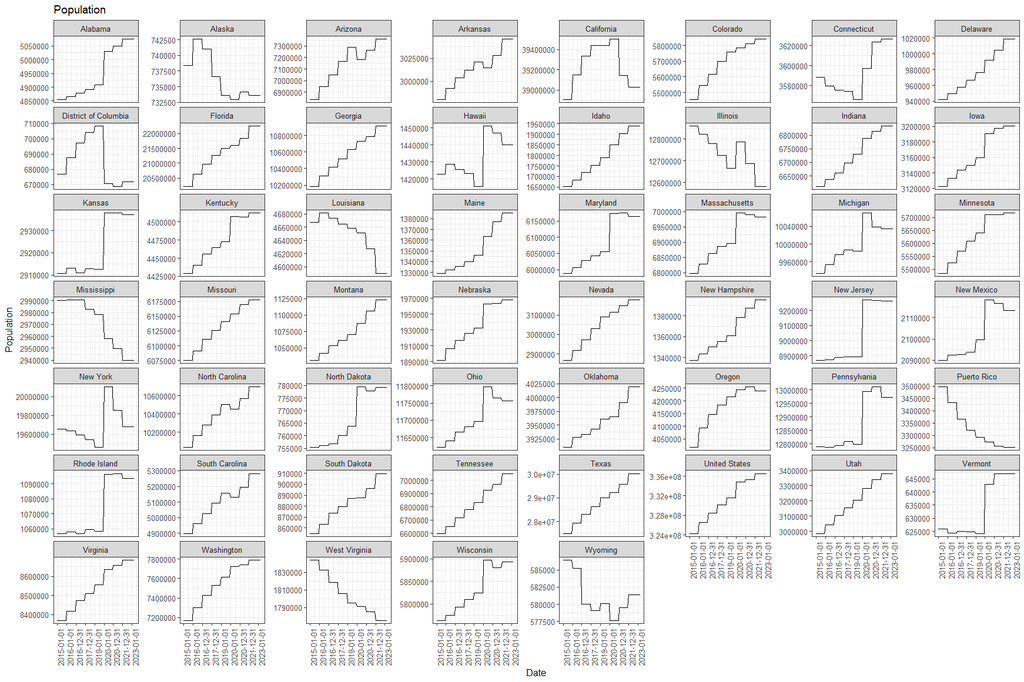

```r
p1 <- ggplot(tmp,
             aes(x = Date,
                 y = Population)) +
  facet_wrap(~ State,
             scale = "free_y") +
  geom_line() +
  scale_x_continuous(breaks = seq.Date(from = min(tmp$Date),
                                       to = max(tmp$Date),
                                       by = 365.25)) +
  ggtitle("Population") +
  theme_bw() +
  theme(legend.position = "none",
        axis.text.x = element_text(angle = 90,
                                   hjust = 1))

# tiff(filename = "tmp/population.tiff",
#      height = 10,
#      width = 15,
#      units = 'in',
#      res = 300,
#      compression = "lzw+p")
# print(p1)
# graphics.off()

p1
```

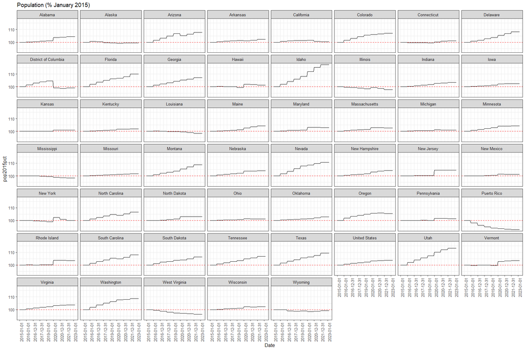

```r
p2 <- ggplot(tmp,
             aes(x = Date,
                 y = pop2015pct)) +
  facet_wrap(~ State) +
  geom_hline(yintercept = 100,
             linetype = "dashed",
             color = "red") +
  geom_line() +
  scale_x_continuous(breaks = seq.Date(from = min(tmp$Date),
                                       to = max(tmp$Date),
                                       by = 365.25)) +
  ggtitle("Population (% January 2015)") +
  theme_bw() +
  theme(legend.position = "none",
        axis.text.x = element_text(angle = 90,
                                   hjust = 1))

# tiff(filename = "tmp/population_pct_jan010.tiff",
#      height = 10,
#      width = 15,
#      units = 'in',
#      res = 300,
#      compression = "lzw+p")
# print(p2)
# graphics.off()

p2
```

## 2.3 Daily death

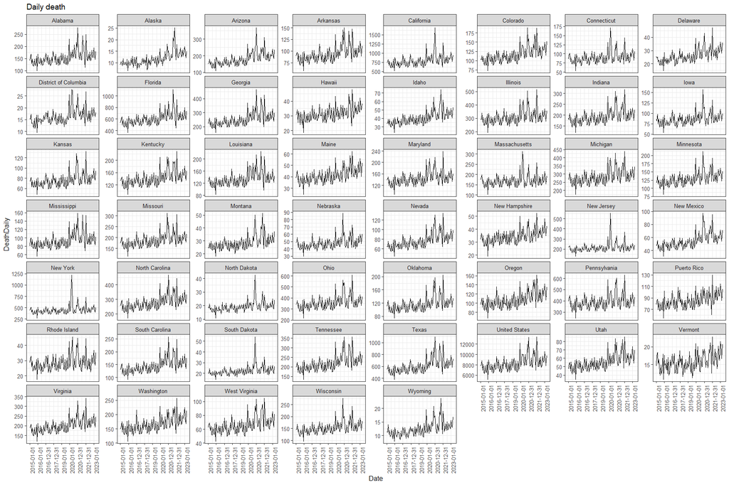

```r
p1 <- ggplot(dt2,
             aes(x = Date,
                 y = DeathDaily)) +
  facet_wrap(~ State,
             scale = "free_y") +
  geom_line() +
  scale_x_continuous(breaks = seq.Date(from = min(dt2$Date),
                                       to = max(dt2$Date),
                                       by = 365.25)) +
  ggtitle("Daily death") +
  theme_bw() +
  theme(legend.position = "none",
        axis.text.x = element_text(angle = 90,
                                   hjust = 1))

# tiff(filename = paste0("tmp/death_daily.tiff"),
#      height = 10,
#      width = 15,
#      units = 'in',
#      res = 300,
#      compression = "lzw+p")
# print(p1)
# graphics.off()

p1
```

## 2.4 COVID-19 only

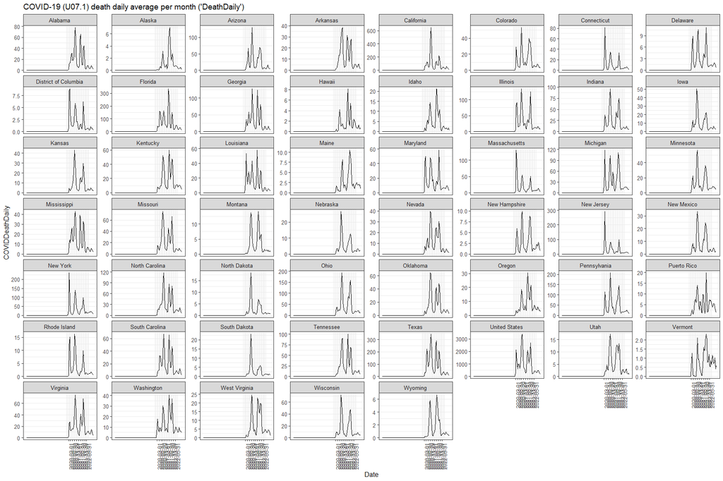

```r
p1 <- ggplot(dt2,
             aes(x = Date,
                 y = COVIDDeathDaily)) +
  facet_wrap(~ State,
             scale = "free_y") +
  geom_line() +
  scale_x_continuous(breaks = seq.Date(from = as.Date("2020-03-01"),
                                       to = as.Date("2022-07-01"),
                                       by = 365.25/4)) +
  ggtitle("COVID-19 (U07.1) death daily average per month ('DeathDaily')") +
  theme_bw() +
  theme(legend.position = "none",
        axis.text.x = element_text(angle = 90,
                                   hjust = 1))

# tiff(filename = "tmp/COVID-19 (U07.1)_death_daily.tiff",
#      height = 10,
#      width = 15,
#      units = 'in',
#      res = 300,
#      compression = "lzw+p")
# print(p1)
# graphics.off()

p1
```

## 2.5 Calculate the rate (no more zeros!)

```r
# Rate = 10^5*(dt1$Deaths + 1)/(daysmonth*(Population + 1))
dt2[, Rate := 10^5*DeathDaily/Population]
```

## 2.6 Daily death rate

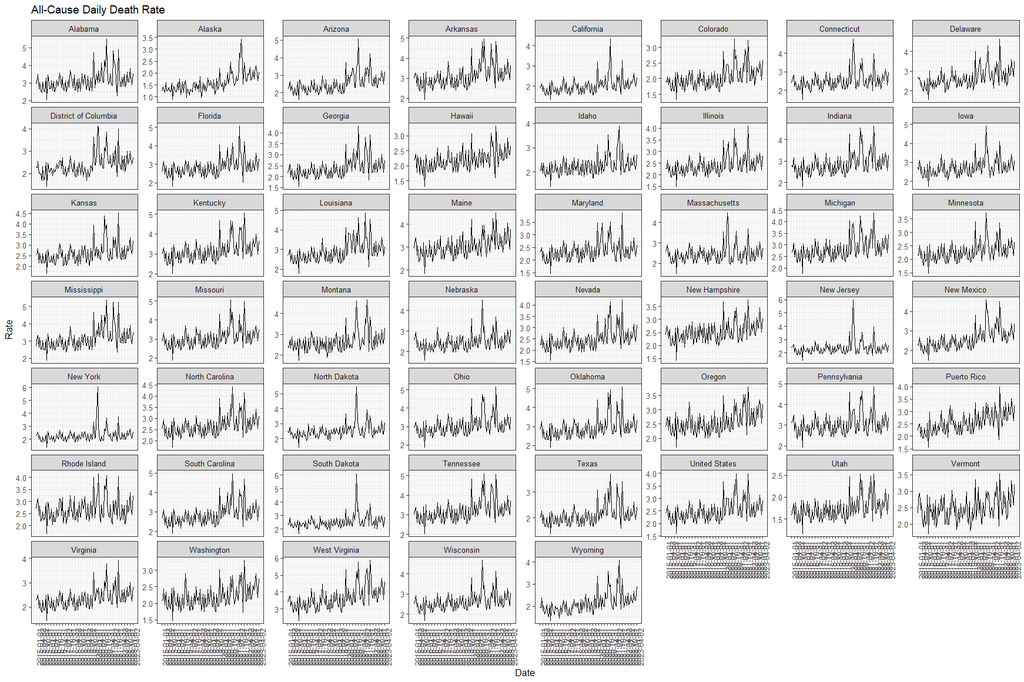

```r
p1 <- ggplot(dt2,
             aes(x = Date,
                 y = Rate)) +
  facet_wrap(~ State,
             scale = "free_y") +
  geom_line() +
  scale_x_continuous(breaks = seq.Date(from = as.Date("2015-01-01"),
                                       to = as.Date("2023-05-01"),
                                       by = 365.25/4)) +
  ggtitle("All-Cause Daily Death Rate") +
  theme_bw() +
  theme(legend.position = "none",
        axis.text.x = element_text(angle = 90,
                                   hjust = 1))

p1
```

# 3 All states together

```r
dt_all <- dt2[, .(all_deaths = sum(Deaths),
                  all_pop = sum(Population),
                  all_covid_deaths = sum(COVID_deaths)),
              by = list(Date,
                        daysmonth)]
dt_all[, all_deaths_daily := all_deaths/daysmonth]
dt_all[, all_covid_deaths_daily := all_covid_deaths/daysmonth]
```

## 3.1 Daily death all states

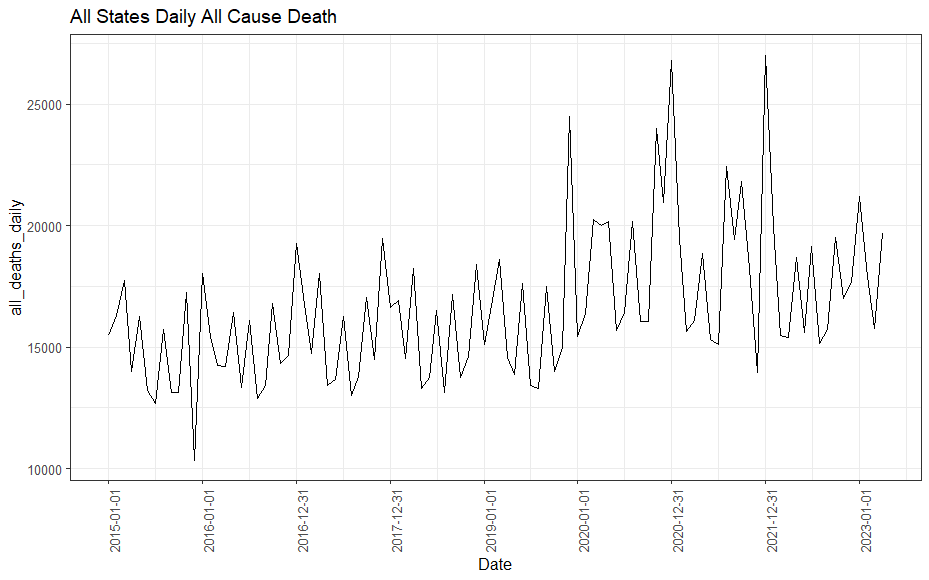

```r
p1 <- ggplot(dt_all,
             aes(x = Date,
                 y = all_deaths_daily)) +
  geom_line() +
  scale_x_continuous(breaks = seq.Date(from = min(dt2$Date),
                                       to = max(dt2$Date),
                                       by = 365.25)) +
  ggtitle("All States Daily All Cause Death") +
  theme_bw() +
  theme(legend.position = "none",
        axis.text.x = element_text(angle = 90,
                                   hjust = 1))

p1
```

## 3.2 Daily COVID-19 death all states

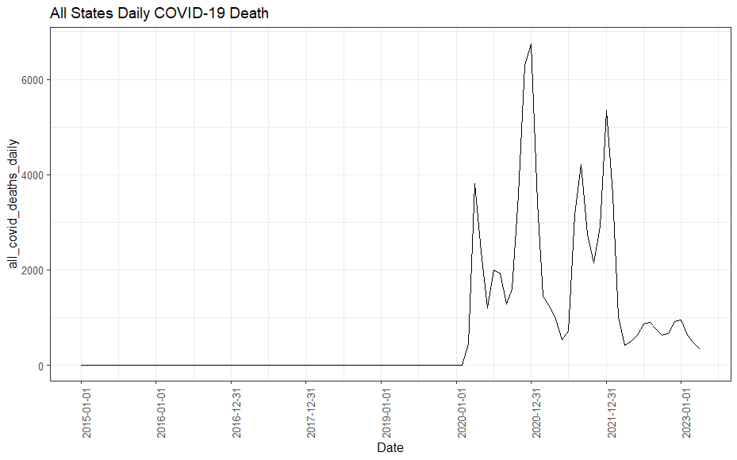

```r
p1 <- ggplot(dt_all,
             aes(x = Date,
                 y = all_covid_deaths_daily)) +
  geom_line() +
  scale_x_continuous(breaks = seq.Date(from = min(dt2$Date),
                                       to = max(dt2$Date),
                                       by = 365.25)) +
  ggtitle("All States Daily COVID-19 Death") +
  theme_bw() +
  theme(legend.position = "none",
        axis.text.x = element_text(angle = 90,
                                   hjust = 1))

p1
```

# 4 Training/Testing/COVID

```r
dt2$set <- "trn"

dt2$set[dt2$Date >= "2019-03-01" &
          dt2$Date < "2020-03-01"] <- "tst"

dt2$set[dt2$Date >= "2020-03-01"] <- "cvd"
```

# 5 Modeling

```r
dt2$dt <- as.numeric(dt2$Date)
dt2$dt_sqr <- dt2$dt^2
```

## 5.1 LM

```r
m1 <- lm(Rate ~ (dt + dt_sqr)*State,
         data = dt2[set == "trn"])

dt2$prd1 <- predict(m1,
                    newdata = dt2)
```

## 5.2 Plot LM

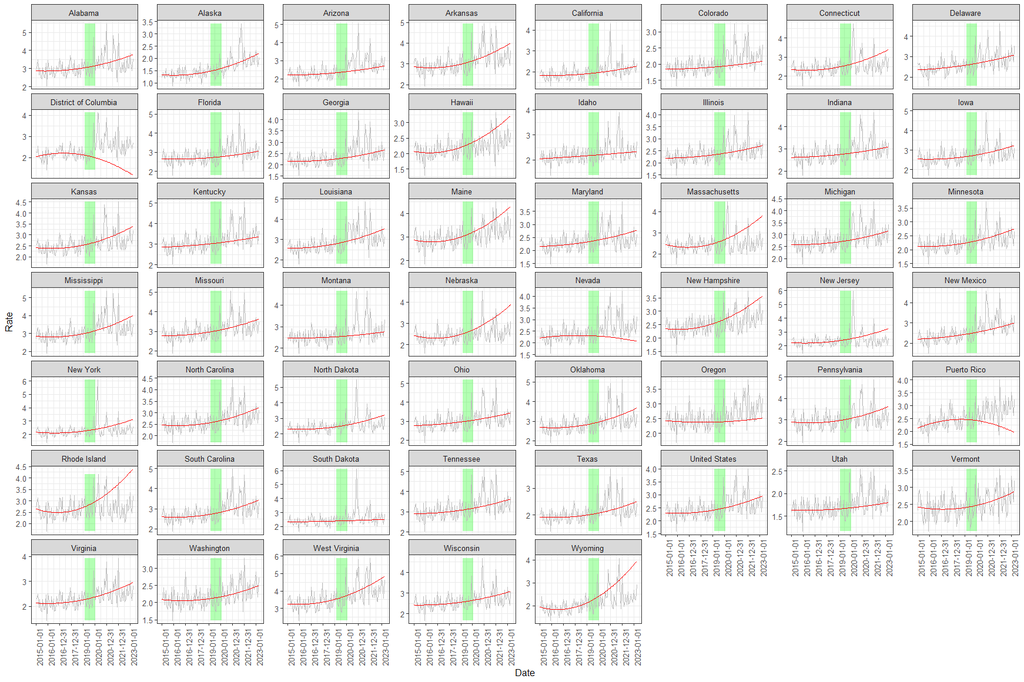

```r
p1 <- ggplot(dt2,
             aes(x = Date,
                 y = Rate,
                 group = State)) +
  facet_wrap(~ State,
             scale = "free_y") +
  geom_ribbon(aes(xmin = min(dt2$Date[dt2$set == "tst"]),
                  xmax = max(dt2$Date[dt2$set == "tst"]),
                  ymin = -Inf,
                  ymax = Inf),
              orientation = "y",
              fill = "green",
              alpha = 0.3) +
  geom_line(color = "gray") +
  geom_line(aes(x = Date,
                y = prd1),
            color = "red") +
  scale_x_continuous(breaks = seq.Date(from = min(dt2$Date),
                                       to = max(dt2$Date),
                                       by = 365.25)) +
  theme_bw() +
  theme(legend.position = "none",
        axis.text.x = element_text(angle = 90,
                                   hjust = 1))
p1
```

## 5.3 NLME

```r
m3 <- nlme(Rate ~ b0 + b1*dt + b2*dt^2 + b3*sin(b4 + b5*dt),
           data = dt2[set == "trn"],
           random = b0 + b1 + b2 + b3 + b4 + b5 ~ 1 | State,
           fixed = b0 + b1 + b2 + b3 + b4 + b5 ~ 1,
           start = list(fixed = c(b0 = 2.5, # linear intercept
                                  b1 = 1, # linear slope
                                  b2 = 1, # square term, i.e. non-linearity of the trend
                                  b3 = 10000, # wave magnitude
                                  b4 = 1, # sin shift to the left
                                  b5 = 0.018)),# wave length(> 1 shortens, < 1 elongates)
           control = nlmeControl(maxIter = 500))
m3
```

```
Nonlinear mixed-effects model fit by maximum likelihood
  Model: Rate ~ b0 + b1 * dt + b2 * dt^2 + b3 * sin(b4 + b5 * dt)
  Data: dt2[set == "trn"]
  Log-likelihood: -602.8925
  Fixed: b0 + b1 + b2 + b3 + b4 + b5 ~ 1
           b0            b1            b2            b3            b4            b5
-1.660665e+01  2.128856e-03 -5.951125e-08  1.750352e-01  1.819978e+00  1.790422e-02

Random effects:
 Formula: list(b0 ~ 1, b1 ~ 1, b2 ~ 1, b3 ~ 1, b4 ~ 1, b5 ~ 1)
 Level: State
 Structure: General positive-definite, Log-Cholesky parametrization
         StdDev       Corr
b0       2.366411e-07 b0     b1     b2     b3     b4
b1       2.060525e-05  1.000
b2       1.390221e-12  1.000  1.000
b3       3.397872e-02  1.000  1.000  1.000
b4       1.450458e-04 -0.999 -1.000 -1.000 -1.000
b5       4.528257e-10  0.930  0.930  0.930  0.930 -0.937
Residual 2.908872e-01

Number of Observations: 2650
Number of Groups: 53
```

```r
dt2$prd3 <- predict(m3,
                    newdata = dt2)

# Save coefficients
betas <- m3$coefficients$fixed

# Save Mean Absolute Percent Error (MAPE)
## All states
mape <- dt2[, .(mape = 100*mean(abs(Rate - prd3)/(Rate))),
            by = set]

## By State
mape_state <- dt2[, .(mape = 100*mean(abs(Rate - prd3)/(Rate))),
                  by = list(State,
                            set)]
```

## 5.4 Plot NLME

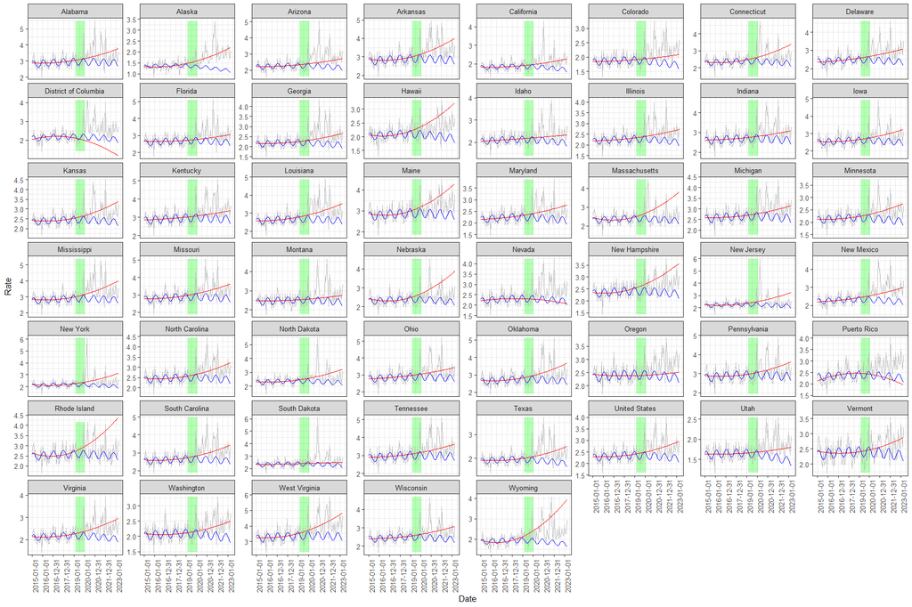

```r
p2 <- p1 +
  geom_line(data = dt2,
            aes(x = Date,
                y = prd3),
            color = "blue")
p2
```

## 5.5 Table 1: Betas

```r
betas
```

```
           b0            b1            b2            b3            b4            b5
-1.660665e+01  2.128856e-03 -5.951125e-08  1.750352e-01  1.819978e+00  1.790422e-02
```

## 5.6 Table 2: MAPE, all states

```r
mape
```

| set | mape |
| --- | --- |
| trn | 10.37786 |
| tst | 12.00117 |
| cvd | 16.94338 |

## 5.7 Table 3: MAPE, by State

```r
tmp <- copy(mape_state)

tmp$set <- factor(tmp$set,
                  levels = c("trn",
                             "tst",
                             "cvd"),
                  labels = c("Training",
                             "Testing",
                             "COVID-19"))

t3 <- dcast.data.table(tmp,
                       State ~ set,
                       value.var = "mape")

head(t3)
```

| State | Training | Testing | COVID-19 |
| --- | --- | --- | --- |
| Alabama | 9.857616 | 12.48624 | 15.76728 |
| Alaska | 13.432613 | 12.45425 | 33.72521 |
| Arizona | 10.567883 | 12.00360 | 23.00497 |
| Arkansas | 10.182615 | 12.48923 | 16.90022 |
| California | 10.666661 | 13.01480 | 19.90187 |
| Colorado | 9.907444 | 11.51895 | 19.48021 |

```r
write.csv(t3,
          file = "tmp/mape_state.csv",
          row.names = FALSE)
```

# 6 CONTINUE HERE 07/16/2023

## 6.1 Save data

```r
dt3 <- rbindlist(dtt)
save(dt3,
     file = "tmp/dt3.RData")
```

# 7 Excess Death

```r
dt3[, Deaths_prd := prd3*daysmonth*Population*10^(-5)]
```

## 7.1 Over the COVID-19 months

```r
ed_cvd <- dt3[set == "cvd",
          .(excess_death_pct_prd = 100*sum(Deaths - Deaths_prd)/sum(Deaths_prd)),
          by = list(State,
                    Cause)]

# summary(ed_cvd)
# levels(ed_cvd$State)
# levels(ed_cvd$Cause)
# range(ed_cvd$excess_death_pct_prd)
#
# ggplot(ed_cvd,
#        aes(x = excess_death_pct_prd)) +
#   facet_wrap(~ State,
#              scale = "free_x") +
#                geom_histogram() +
#   theme_bw()
#
# ggplot(ed_cvd,
#        aes(x = excess_death_pct_prd)) +
#   facet_wrap(~ Cause,
#              scale = "free_x") +
#                geom_histogram() +
#   theme_bw()

t_ed_cvd <- dcast.data.table(data = ed_cvd,
                             State ~ Cause,
                             value.var = "excess_death_pct_prd")
write.csv(t_ed_cvd,
          file = "tmp/t_ed_cvd.csv",
          row.names = FALSE)
t_ed_cvd
```

## 7.2 Over the Testing months

```r
ed_tst <- dt3[set == "tst",
              .(excess_death_pct_prd = 100*sum(Deaths - Deaths_prd)/sum(Deaths_prd)),
              by = list(State,
                        Cause)]

t_ed_tst <- dcast.data.table(data = ed_tst,
                             State ~ Cause,
                             value.var = "excess_death_pct_prd")
write.csv(t_ed_tst,
          file = "tmp/t_ed_tst.csv",
          row.names = FALSE)
t_ed_tst
```

## 7.3 Plot

```r
ci_tst <- ed_tst[, .(mu = mean(excess_death_pct_prd),
                     sem = sd(excess_death_pct_prd)/sqrt(.N)),
                 by = Cause]
ci_tst[, llci := mu - 1.96*sem]
ci_tst[, ulci := mu + 1.96*sem]
ci_tst

p1 <- ggplot(ci_tst,
             aes(x = Cause,
                 y = mu,
                 ymin = llci,
                 ymax = ulci)) +
  geom_hline(yintercept = 0,
             linetype = "dashed",
             color = "red") +
  geom_errorbar(width = 0.2) +
  geom_point(shape = 21,
             size = 3,
             fill = "white") +
  geom_point(data = ed_cvd,
             aes(x = Cause,
                 y = excess_death_pct_prd,
                 group = State),
             shape = 21,
             size = 2,
             fill = "green",
             alpha = 0.5,
             position = position_dodge(0.3),
             inherit.aes = FALSE) +
  scale_y_continuous("% Predicted") +
  ggtitle("") +
  theme_bw() +
  theme(legend.position = "none",
        axis.text.x = element_text(angle = 45,
                                   hjust = 1))

tiff(filename = paste0("tmp/tst_cvd_pctextradeath.tiff"),
     height = 8,
     width = 8,
     units = 'in',
     res = 300,
     compression = "lzw+p")
print(p1)
graphics.off()

p1
```

## 7.4 Transform data with DNAMR::trans2t

```r
# ed[, expp_t := trans2t(excess_death_pct_prd)$x]
# # No need? Didn't run by State or Cause!
#
# ggplot(ed,
#        aes(x = expp_t)) +
#   facet_wrap(~ State,
#              scale = "free_x") +
#   geom_histogram() +
#   theme_bw()
```

## 7.5 PCA

```r
# dt_pca <- dcast.data.table(data = t3,
#                            State ~ `Cause of Death`,
#                            value.var = "Training")

dt_pca <- dcast.data.table(data = ed,
                           State ~ Cause,
                           value.var = "excess_death_pct_prd")

write.csv(dt_pca,
          file = "tmp/dt_pca.csv",
          row.names = FALSE)
```

```r
m1 <- prcomp(dt_pca[, -1],
             center = TRUE,
             scale. = FALSE)
summary(m1)
```

```r
# Biplot while keep only the most important variables (Javier)----
# Select PC-s to pliot (PC1 & PC2)
choices <- 1:2
# Scores, i.e. points (df.u)
dt.scr <- data.table(m1$x[, choices])

# # Add grouping variable
dt.scr$State <- dt_pca$State
dt.scr

# Loadings, i.e. arrows (df.v)
dt.rot <- as.data.frame(m1$rotation[, choices])
dt.rot$feat <- rownames(dt.rot)
dt.rot <- data.table(dt.rot)
dt.rot
dt.load <- melt.data.table(dt.rot,
                           id.vars = "feat",
                           measure.vars = 1:2,
                           variable.name = "pc",
                           value.name = "loading")
dt.load$feat <- factor(dt.load$feat,
                     levels = unique(dt.load$feat))
dt.load

# Axis labels
u.axis.labs <- paste(colnames(dt.rot)[1:2],
                     sprintf('(%0.1f%% explained var.)',
                             100*m1$sdev[choices]^2/sum(m1$sdev^2)))
u.axis.labs
```

```r
scl <- 35

p1 <- ggplot(data = dt.rot,
             aes(x = PC1,
                 y = PC2)) +
  geom_point(data = dt.scr,
             # aes(fill = grp),
             shape = 21,
             size = 2,
             alpha = 0.5) +
  geom_text(data = dt.scr,
            aes(label = State),
            size = 3,
            hjust = 0.5,
            color = "red") +
  geom_segment(aes(x = 0,
                   y = 0,
                   xend = scl*PC1,
                   yend = scl*PC2),
               arrow = arrow(length = unit(1/2, 'picas')),
               color = "black",
               linewidth = 1.2) +
  geom_text(aes(x = 1.1*scl*PC1,
                y = 1.1*scl*PC2,
                label = substr(x = dt.rot$feat,
                               start = 1,
                               stop = 10)),
            size = 4,
            hjust = 0.5) +
  scale_x_continuous(u.axis.labs[1]) +
  scale_y_continuous(u.axis.labs[2]) +
  scale_fill_discrete(name = "Group") +
  ggtitle("Daily Death (% Predicted) PCA") +
  theme_bw() +
  theme(plot.title = element_text(hjust = 0.5,
                                  size = 20))

tiff(filename = "tmp/biplot_excess_dath_pct.tiff",
     height = 7,
     width = 7,
     units = 'in',
     res = 300,
     compression = "lzw+p")
print(p1)
graphics.off()

p1
```

# 8 Diabetes Death in CA Only

## 8.1 Sinusoidal model NLS

```r
diab_ca <- dt3[Cause == "Diabetes mellitus (E10-E14)" &
                 State == "California"]

lm0 <- lm(Rate ~ dt + dt_sqr,
          data = diab_ca[set == "trn"])
summary(lm0)

m3 <- nls(Rate ~ b0 + b1*dt + b2*dt^2 + b3*sin(b4 + b5*dt),
          data = diab_ca[set == "trn"],
          # random = b0 + b1 + b2 + b3 + b4 + b5 ~ 1 | State,
          # fixed = b0 + b1 + b2 + b3 + b4 + b5 ~ 1,
          start = list(b0 = lm0$coefficients[1],
                       b1 = lm0$coefficients[2],
                       b2 = 0, # m0$coefficients[3],
                       b3 = 10000,
                       b4 = 1,
                       b5 = 1/60)) #  originally 0.018, 1/60=0.017
summary(m3)

diab_ca$prd4 <- predict(m3,
                        newdata = diab_ca)
```

## 8.2 Plot

```r
p1 <- ggplot(diab_ca,
             aes(x = Date,
                 y = Rate,
                 group = Cause)) +
  geom_ribbon(aes(xmin = min(diab_ca$Date[diab_ca$set == "tst"]),
                  xmax = max(diab_ca$Date[diab_ca$set == "tst"])),
              orientation = "y",
              fill = "green",
              alpha = 0.3) +
  geom_line(color = "gray") +
  geom_line(aes(x = Date,
                y = prd1), # prediction from lm
            color = "black",
            linetype = "dashed") +
  geom_line(data = diab_ca,
            aes(x = Date,
                y = prd3), # prediction from lme
            color = "blue") +
  geom_line(data = diab_ca,
            aes(x = Date,
                y = prd4), # prediction from nls
            color = "red") +
  scale_x_continuous(breaks = seq.Date(from = min(diab_ca$Date),
                                       to = max(diab_ca$Date),
                                       by = 365.25)) +
  ggtitle(paste(diab_ca$Cause[1],
                diab_ca$State[1],
                sep = ": ")) +
  theme_bw() +
  theme(legend.position = "none",
        axis.text.x = element_text(angle = 90,
                                   hjust = 1))

p1
```

## 8.3 Fast Fourier Transform

```r
# x <- 1:4
# fft(x)
# xx <- fft(fft(x), inverse = TRUE)/length(x)
#
# xx <- fft(z = diab_ca$Rate[diab_ca$set == "trn"])
# xx
```

## 8.4 Spectral density of a time serie

```r
xx <- spectrum(diab_ca$Rate[diab_ca$set == "trn"])

# The highest peak is around the 12-months cycle
abline(v = 1/12,
       col = 2, # red
       lty = 2,
       lw = 2)

# Other top peaks
abline(v = 1/60,
       col = 3, # blue
       lty = 2)
abline(v = 1/6,
       col = 4, # green
       lty = 2)

tmp <- data.table(x = 1/xx$freq,
                  y = xx$spec)
ggplot(tmp[x < 25],
       aes(x = x,
           y = y)) +
  geom_line() +
  scale_x_continuous("Months",
                     breaks = seq(from = 0,
                                  to = 200,
                                  by = 6)) +
  scale_y_continuous("Spectral Density") +
  geom_vline(xintercept = c(6, 12),
             color = "red",
             linetype = "dashed") +
  theme_bw()
```

## 8.5 Classical Seasonal Decomposition by Moving Averages

```r
xx <- ts(data = diab_ca$Rate[diab_ca$set == "trn"],
         frequency = 12)

m11 <- decompose(xx)
summary(m11)
plot(m11)
```

## 8.6 Plot seasonal effect and trend

```r
diab_ca$seas1 <- diab_ca$trend1 <- NA
diab_ca$seas1[diab_ca$set == "trn"] <- c(m11$seasonal)
diab_ca$trend1[diab_ca$set == "trn"] <- c(m11$trend)
diab_ca[, freq1 := seas1 + trend1]

p1 <- ggplot(diab_ca,
             aes(x = Date,
                 y = Rate,
                 group = Cause)) +
  geom_ribbon(aes(xmin = min(diab_ca$Date[diab_ca$set == "tst"]),
                  xmax = max(diab_ca$Date[diab_ca$set == "tst"])),
              orientation = "y",
              fill = "green",
              alpha = 0.3) +
  geom_line(color = "gray") +
  geom_line(aes(x = Date,
                y = trend1),
            color = "blue") +
  geom_line(aes(x = Date,
                y = freq1),
            color = "red") +
  scale_x_continuous(breaks = seq.Date(from = min(diab_ca$Date),
                                       to = max(diab_ca$Date),
                                       by = 365.25)) +
  ggtitle(paste(diab_ca$Cause[1],
                diab_ca$State[1],
                sep = ": ")) +
  theme_bw() +
  theme(legend.position = "none",
        axis.text.x = element_text(angle = 90,
                                   hjust = 1))
p1
```

```r
diab_ca$dt <- as.numeric(factor(diab_ca$Date))
diab_ca$dt2 <- diab_ca$dt^2

tm1 <- lm(trend1 ~ dt + dt2,
          data = diab_ca[set == "trn", ])
tm1

diab_ca$trend1_pred <- predict(tm1,
                               newdata = list(dt = diab_ca$dt,
                                              dt2 = diab_ca$dt2))
diab_ca[set == "trn",
        freq2 := seas1 + trend1_pred]

plot(trend1_pred ~ dt,
     data = diab_ca,
     type = "l")
lines(trend1 ~ dt,
     data = diab_ca,
     col = 2)

p1 <- ggplot(diab_ca,
             aes(x = Date,
                 y = Rate,
                 group = Cause)) +
  geom_ribbon(aes(xmin = min(diab_ca$Date[diab_ca$set == "tst"]),
                  xmax = max(diab_ca$Date[diab_ca$set == "tst"])),
              orientation = "y",
              fill = "green",
              alpha = 0.3) +
  geom_line(color = "gray") +
  geom_line(aes(x = Date,
                y = trend1_pred),
            color = "blue") +
  geom_line(aes(x = Date,
                y = freq2),
            color = "red") +
  scale_x_continuous(breaks = seq.Date(from = min(diab_ca$Date),
                                       to = max(diab_ca$Date),
                                       by = 365.25)) +
  ggtitle(paste(diab_ca$Cause[1],
                diab_ca$State[1],
                sep = ": ")) +
  theme_bw() +
  theme(legend.position = "none",
        axis.text.x = element_text(angle = 90,
                                   hjust = 1))
p1
```

```r
diab_ca$seas1_pred <- NA
diab_ca$seas1_pred[1:144] <- rep(diab_ca$seas1[1:12],
                                 rep = 12)
diab_ca$seas1_pred[145:150] <- diab_ca$seas1[1:6]

diab_ca[, freq3 := seas1_pred + trend1_pred]

p1 <- ggplot(diab_ca,
             aes(x = Date,
                 y = Rate,
                 group = Cause)) +
  geom_ribbon(aes(xmin = min(diab_ca$Date[diab_ca$set == "tst"]),
                  xmax = max(diab_ca$Date[diab_ca$set == "tst"])),
              orientation = "y",
              fill = "green",
              alpha = 0.3) +
  geom_line(color = "gray") +
  geom_line(aes(x = Date,
                y = trend1_pred),
            color = "blue") +
  geom_line(aes(x = Date,
                y = freq3),
            color = "red") +
  scale_x_continuous(breaks = seq.Date(from = min(diab_ca$Date),
                                       to = max(diab_ca$Date),
                                       by = 365.25)) +
  ggtitle(paste(diab_ca$Cause[1],
                diab_ca$State[1],
                sep = ": ")) +
  theme_bw() +
  theme(legend.position = "none",
        axis.text.x = element_text(angle = 90,
                                   hjust = 1))
diab_ca[set == "trn",
        freq2 := seas1 + trend1_pred]
p1
```

## 8.7 MAPE

```r
# Seasonal predictions
diab_ca[, .(mape = 100*mean(abs(Rate - freq3)/Rate)),
        by = set]

# NLME predictions
t(t3[State == "California" &
     `Cause of Death` == "Diabetes mellitus (E10-E14)", ])
```

## 8.8 Subtract seasonal effect (12-month cycle)

```r
# diab_ca$Rate2 <- diab_ca$Rate - c(m11$seasonal)
diab_ca[, Rate2 := Rate - seas1 - trend1_pred]
```

## 8.9 Rerun spectral analysis

```r
xx <- spectrum(diab_ca$Rate2[diab_ca$set == "trn"])

tmp <- data.table(x = 1/xx$freq,
                  y = xx$spec)
ggplot(tmp[x < 25],
       aes(x = x,
           y = y)) +
  geom_line() +
  scale_x_continuous("Months",
                     breaks = seq(from = 0,
                                  to = 200,
                                  by = 6)) +
  scale_y_continuous("Spectral Density") +
  geom_vline(xintercept = c(13.3),
             color = "red",
             linetype = "dashed") +
  theme_bw()
```

```r
xx <- ts(data = diab_ca$Rate2[diab_ca$set == "trn"],
         frequency = 13)

m12 <- decompose(xx)
summary(m12)
plot(m12)
```